# Kontaktmodell

Das Kontaktmodell beschreibt die räumliche Ausbreitung einer Infektion durch direkten Kontakt von sich bewegenden Menschen (Punkte).  
Als Infektionsradius definieren wir den maximalen Abstand, der die Übetragung der Infektionen ermöglicht. Wird ein gesunder Fußgänger den kritschen Mindestabstand zum Infizierten Individuum überschreiten, wird sich dieser auch infizieren.

##### Implimentieren grundlegender Parameter

```matlab
Nx=10; %Anzahl von Punkten in x-Richtung
Ny=20; %Anzahl von Punkten in y-Richtung
Zeitschritte=3;%pro eine Zeiteinheit T=1    ???
radiusInf=0.80;% innerhalb dieses Radius infiziert sich ein Indivduum
T=3 ; %3 Zeiteinheiten
g=0.50;% Bewegungsgeschwindigkeit der Menschen - Einheit der Geschwindigkeit????

%------------------------
x=[1:Nx]; % x läuft von 1 bis (hier 10) in einer Schritten in einem Zeilenvektor
y=[1:Ny]; % y läuft von 1 bis (hier 20) in einer Schritten in einem Zeilenvektor
dt=1/Zeitschritte; %???

[x,y]=meshgrid (x,y); %erstellt Punktegitter (zwei Matrizen x,y, die die x- und y-Koordinaten der Punkte (Menschen) enthalten)
```

##### Festlegen der x,y- Koordinaten bzw die Indexen (der Matrixkomponenten) des ersten Infizierten

Der erste Infizierte befindet sich in der Mitte.

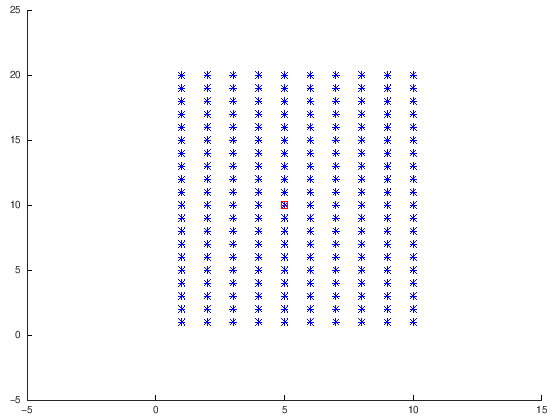

```matlab
xInf=x(1, Nx/2); % x-Koordinate des Infizierten (Zeile  1, Spalte 5)
yInf=y(Ny/2,1);    % y-Koordinate des Infizierten (Zeile 10, Spalte 1)
IndInf2=Nx/2;    % Index 2 des Infizierten (Spalte)
IndInf1=Ny/2;    % Index 1 des Infizierten (Zeile)
IndInf1neu=IndInf1; % Index Neuinfizierten (Zeile)
IndInf2neu=IndInf2; % Index Neuinfizierten (Spalte)

close all;

%Plotten des Infizierten
figure (1)
hold on;
plot(x,y, '*b') ; %stellt blauen Punkte (Menschen) im Gitter dar - statisch, ohne Bewegung
plot(xInf,yInf, 'sr') ; %stellt Infizierten mit rotem Rahmen dar
axis([-5 15 -5 25]); % x-Achse läuft von -5 bis 15, y-Achse läuft von -5 bis 25
hold off;
%mit folgenden Befehlen kann man die Bilder speichern und für weitere Bearbeitung verwenden (Videos, Animationen)
%test=["images/Fig_", num2str(1),".jpg"];
%saveas(1, test)
```

#### Generieren von Bewegung der Punkte

Im Folgenden wird die Bewegung der Punkte (Fußgänger) generiert. Die Bewegungsrichtung sowie die zurückgelegte Entfernung soll zufällig sein. Dies geschieht mit dem im Folgenden beschriebenen Befehl.

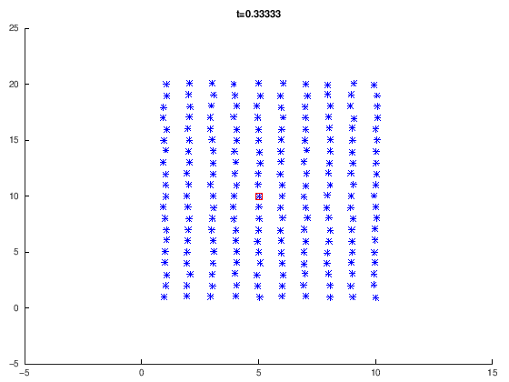

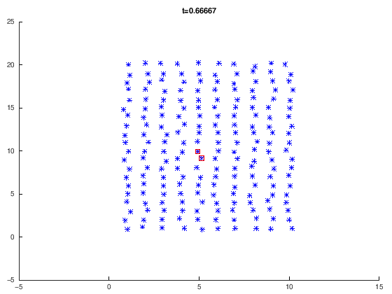

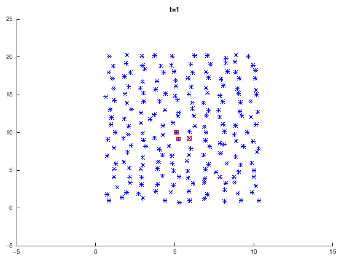

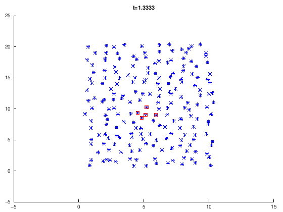

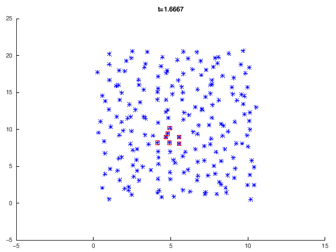

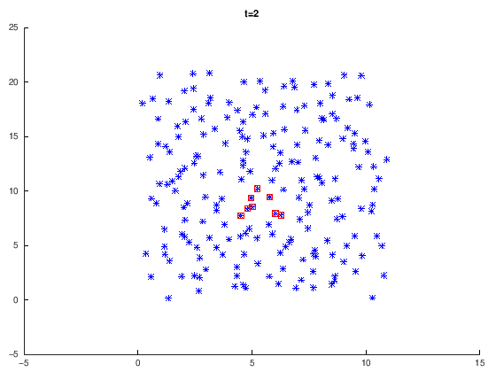

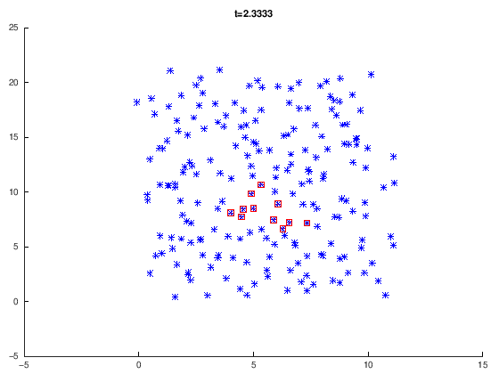

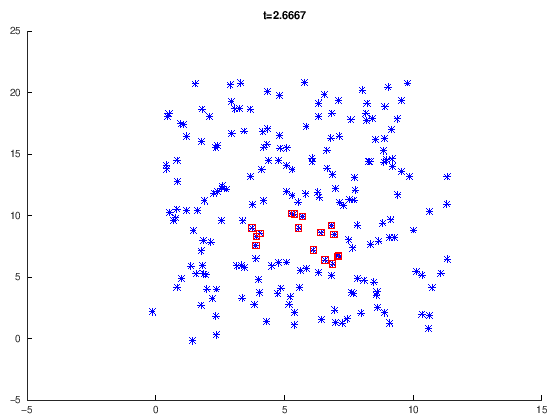

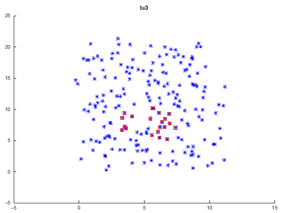

```matlab
% Es werden mehrere Bewegungen durchgeführt, sodass nicht eine einmalige Bewegung stattfindet, sondern die Punkte (Menschen) im Gitter wandern und schließlich aufeinander treffen.
for  i=1:T*Zeitschritte

%Mit dem Befehl 'rand(Ny,Nx)' wird eine Matrix (Nx x Ny) der Zufallszahlen zwischen 0 und 1 generiert, mit 'rand(Ny,Nx)-0.5' werden Zufallszahlen zwischen -0.5 und 0.5 generiert.
%Die neue Zielpositionen der wandernden Punkte werden durch Addition der Zufallszahl zwischen -0.5 und 0.5 zu jeder x,y- Koordinaten generiert und mit der gegebenen Geschwindigkeit g skalliert
neuPosX=x.+g.*rand(Ny,Nx)-0.5*g;
neuPosY=y.+g*rand(Ny,Nx)-0.5*g;

%In jedem Zeitschritt i wird zur aktuellen Position ein entsprechender Bruchteil i*dt der noch ausstehenden Strecke in beide Richtungen addiert.
neuX=x.+1*(neuPosX.-x)*i*dt;
neuY=y.+1*(neuPosY.-y)*i*dt;

%Anschließend wird die neu erreichte Position nach einem Zeitschritt i in x gespeichert, sodass die for-Schleife wieder durchlaufen wird.
x=neuX;
y=neuY;

  figure (i+1)
  title(['t=' num2str(i*dt)])
  axis([-5 25 -5 25]);
   hold on
    plot(neuX,neuY, '*b') ;
    axis([-5 15 -5 25]);

%neue Infizierungen:
%In Vektoren IndInf1, IndInf2 sind die i- und j-Indexen der (x,y)-Koordinaten der bereits Infizierten gespeichert.
    zahler=1;
       for  k1=1:length(IndInf1) %Länge des aktuell gespeicherten Vektors des Infizierten
        for  j=1:Nx
         for  l=1:Ny
         %die aktuellen Positionen der Füßgänger-Punkte werden mit den Positionen der Infizierten abgeglichen (Abstand wird berechnet)
           abstand=norm([neuX(l,j)-neuX(IndInf1(k1),IndInf2(k1)), neuY(l,j)-neuY(IndInf1(k1),IndInf2(k1))]);
           %wenn der Abstand zum Infizierten unter dem Ansteckunsradius liegt, wird  der l,j-te  Punkt infiziert (mit rotem Quadrat                  gekenzeichnet)
             if  abstand<radiusInf
               abstand;
               plot(neuX(l,j),neuY(l,j), 'sr') %Färbe rot
                % der Vektor der Infizierten wird untersucht, falls die l,j-Indexen des aktuellen Punkten nicht unter den
                 %infizierten Indexen auftauchen, werden  die l,j-Indexen des aktuell Infizierten zu den neuen Vektoren der                                Infizierten-Indexen IndInf1neu, IndInf2neu zugefügt.
                 % es wird überprüft, ob der Infizierte schon infiziert ist, wenn nicht, dann wird er zu den Infizierten hinzugefügt
                %(Grund: Speicheroptimierung)
               k2=1;
                 while  k2 <=length(IndInf1)&&(l!=IndInf1neu(k2) || j!=IndInf2neu(k2))
                   k2=k2+1;
                 endwhile
                   if   k2 >length(IndInf1)
                     IndInf1neu=[IndInf1neu l];
                     IndInf2neu=[IndInf2neu j];
                   endif
              endif
          endfor
         endfor
        endfor
     IndInf1=IndInf1neu;
     IndInf2=IndInf2neu;
    %test=["images/Fig_", num2str(i+1),".jpg"];
    %saveas(i+1, test)
    hold off
  lengt=length(IndInf1);
endfor
```

[figure not shown]

## Fazit

#### Ansteckungsradius

Nach Veränderung des Ansteckungsradius lässt sich feststellen, dass bei größerem Radius mehr Menschen innerhalb kürzerer Zeit infiziert werden als bei einem kleineren Ansteckungsradius.

#### Bewegungsgeschwindigkeit

Nach Veränderung der Bewegungsgeschwindigkeit lässt sich ebenfalls feststellen, dass bei einer höheren Bewegungsgeschwindigkeit die Infektion schneller verläuft als bei einer niedrigen.

#### Startposition des Infizierten

Je weiter der Infizierte am Rand liegt, desto weniger Menschen werden angesteckt innerhalb der gleichen Zeit, wenn der Infizierte in der Mitte startet.

### Schwächen des Modells

- In der Realität gesunden die Menschen nach einiger Zeit oder sterben, jedoch bleiben sie nicht dauerhaft infiziert wie in diesem Modell.
- Auch bewegen sich die Menschen außerhalb des Gitters und es kommen Menschen dazu und es gehen Menschen wieder weg. Die Anzahl der Menschen bleibt nicht konstant in der Realität.  
  -> Pendler-und Reiseverkehr werden nicht berücksichtigt (Autobeispiel)  
  -> Es findet kein Austausch zwischen verschiedenen Gebieten statt
- Weiterhin wird nicht die Zeit betrachtet, wie lange ein Infizierter mit einem "gesunden" Menschen in Kontakt steht. Denn laut der aktuellen Forschung überträgt sich COVID-19 erst nach 15-minütigen Kontakt mit einer Person.